# Un modello statistico per prevedere il peso dei neonati

Davide Incaini

2024-10-20

```r
library(dplyr)
library(gt)
library(rstatix)
library(moments)
library(ggplot2)
library(tidyr)
library(patchwork)
library(ggpubr)
library(MASS)
```

## 1-Importa il dataset “neonati.csv” e controlla che sia stato letto correttamente dal software

```r
data= read.csv("neonati.csv",
               stringsAsFactors = T)
data$Fumatrici = ifelse(data$Fumatrici == 0, "NO", "SÌ")
data$Fumatrici = as.factor(data$Fumatrici)
```

```r
summary(data)
```

```
##    Anni.madre     N.gravidanze     Fumatrici   Gestazione         Peso
##  Min.   : 0.00   Min.   : 0.0000   NO:2396   Min.   :25.00   Min.   : 830
##  1st Qu.:25.00   1st Qu.: 0.0000   SÌ: 104   1st Qu.:38.00   1st Qu.:2990
##  Median :28.00   Median : 1.0000             Median :39.00   Median :3300
##  Mean   :28.16   Mean   : 0.9812             Mean   :38.98   Mean   :3284
##  3rd Qu.:32.00   3rd Qu.: 1.0000             3rd Qu.:40.00   3rd Qu.:3620
##  Max.   :46.00   Max.   :12.0000             Max.   :43.00   Max.   :4930
##    Lunghezza         Cranio    Tipo.parto Ospedale   Sesso
##  Min.   :310.0   Min.   :235   Ces: 728   osp1:816   F:1256
##  1st Qu.:480.0   1st Qu.:330   Nat:1772   osp2:849   M:1244
##  Median :500.0   Median :340              osp3:835
##  Mean   :494.7   Mean   :340
##  3rd Qu.:510.0   3rd Qu.:350
##  Max.   :565.0   Max.   :390
```

#### Dall’analisi dei risultati del summary ho riscontrato valori anomali per la variabile anni madre. In particolare il minimo anni madre uguale a zero mi porta a dover approfondire l’analisi.

#### Grafico il peso in funzione degli anni madre per avere una visione rapida dei possibili valori anomali.

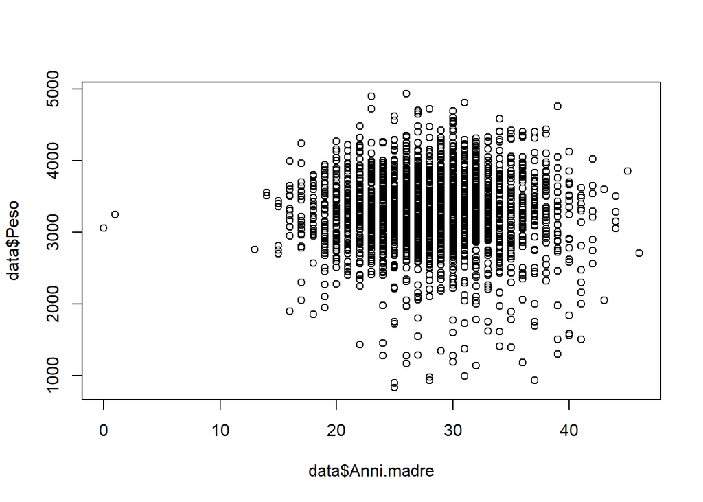

```r
plot(data$Peso~data$Anni.madre)
```

#### Il grafico conferma la presenza di due valori anomali che decido quindi di eliminare dal dataset.

#### Rimuovo i dati con anni madre inferiori a 10 anni.

```r
dati_filtrati = data %>%
  filter (Anni.madre > 10)

attach(dati_filtrati)
```

## 2-Descrivi il dataset, la sua composizione, il tipo di variabili e l’obbiettivo dello studio

```r
classifica_variabili <- function(df) {
  tibble(
    Variabile = names(df),
    Tipo = sapply(df, function(col) case_when(
      is.numeric(col) ~ "Numerica",
      is.factor(col) ~ "Categoriale")))}

tipo_variabili = classifica_variabili(dati_filtrati)
print(tipo_variabili)
```

```
## # A tibble: 10 × 2
##    Variabile    Tipo
##    <chr>        <chr>
##  1 Anni.madre   Numerica
##  2 N.gravidanze Numerica
##  3 Fumatrici    Categoriale
##  4 Gestazione   Numerica
##  5 Peso         Numerica
##  6 Lunghezza    Numerica
##  7 Cranio       Numerica
##  8 Tipo.parto   Categoriale
##  9 Ospedale     Categoriale
## 10 Sesso        Categoriale
```

#### Il dataset è composto da 10 variabili: 6 variabili numeriche e 4 variabili categoriali.

#### L’obiettivo è quello di creare un modello di regressione lineare multipla con il quale si vuole cercare di prevedere il peso dei neonati, la variabile riposta, al variare di tutti i regressori utilizzati che introdurrò nel modello, sia numerici che categoriali.

## 3-Indaga le variabili effettuando una breve analisi descrittiva, utilizzando indici e strumenti grafici che conosci

```r
# Creo un sottonsieme del dataset filtrato per calcolare gli indici delle variabili numeriche

data_indici = dati_filtrati %>%
  select_if(is.numeric)

statistiche_descrittive = get_summary_stats(data_indici)
CV = ((statistiche_descrittive$sd/statistiche_descrittive$mean)*100)
asimmetria = sapply(data_indici,skewness)
curtosi= sapply(data_indici,kurtosis)

tabella_statistiche_descrittive = cbind(statistiche_descrittive,CV,asimmetria,curtosi)
gt(tabella_statistiche_descrittive)
```

| variable | n | min | max | median | q1 | q3 | iqr | mad | mean | sd | se | ci | CV | asimmetria | curtosi |
| --- | --- | --- | --- | --- | --- | --- | --- | --- | --- | --- | --- | --- | --- | --- | --- |
| Anni.madre | 2498 | 13 | 46 | 28 | 25 | 32 | 7 | 4.448 | 28.186 | 5.217 | 0.104 | 0.205 | 18.509189 | 0.1510624 | 2.894394 |
| N.gravidanze | 2498 | 0 | 12 | 1 | 0 | 1 | 1 | 1.483 | 0.982 | 1.281 | 0.026 | 0.050 | 130.448065 | 2.5134123 | 13.981627 |
| Gestazione | 2498 | 25 | 43 | 39 | 38 | 40 | 2 | 1.483 | 38.980 | 1.869 | 0.037 | 0.073 | 4.794767 | -2.0651309 | 11.255516 |
| Peso | 2498 | 830 | 4930 | 3300 | 2990 | 3620 | 630 | 459.606 | 3284.184 | 525.229 | 10.509 | 20.607 | 15.992679 | -0.6474036 | 5.028753 |
| Lunghezza | 2498 | 310 | 565 | 500 | 480 | 510 | 30 | 22.239 | 494.696 | 26.329 | 0.527 | 1.033 | 5.322259 | -1.5145746 | 9.480930 |
| Cranio | 2498 | 235 | 390 | 340 | 330 | 350 | 20 | 14.826 | 340.029 | 16.429 | 0.329 | 0.645 | 4.831647 | -0.7850906 | 5.944870 |

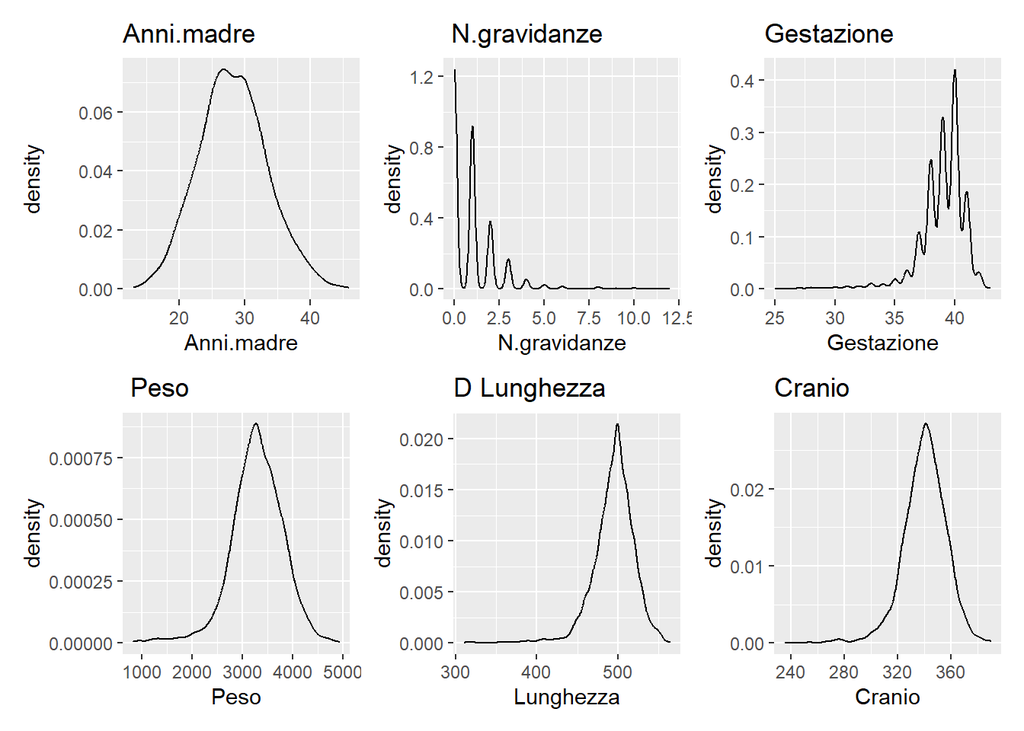

```r
p1 = ggplot(data_indici, aes(x = Anni.madre)) +
  geom_density() +
  ggtitle("Anni.madre")

p2 = ggplot(data_indici, aes(x = N.gravidanze)) +
  geom_density() +
  ggtitle(" N.gravidanze")

p3 = ggplot(data_indici, aes(x = Gestazione)) +
  geom_density() +
  ggtitle("Gestazione")

p4 = ggplot(data_indici, aes(x = Peso)) +
  geom_density() +
  ggtitle(" Peso")

p5 = ggplot(data_indici, aes(x = Lunghezza)) +
  geom_density() +
  ggtitle("D Lunghezza")

p6 = ggplot(data_indici, aes(x = Cranio)) +
  geom_density() +
  ggtitle("Cranio")


# Trasforma i dati utilizzati per calcolare gli indici delle variabili numeriche in formato long
# Il formato long mi serve per poter creare il boxplot
data_indici_long = pivot_longer(data_indici,
                                cols = everything(),
                                names_to = "Variabile",
                                values_to = "Valore")


# Crea i boxplot affiancati e colorati
boxplot_data_indici = ggplot(data_indici_long,
       aes(x = "", y = Valore, fill = Variabile))+
  geom_boxplot() +
  facet_wrap(~ Variabile, scales = "free_y",ncol=6) +
  labs(x = NULL)+
  theme(legend.position = "none",
        legend.title = element_blank(),
        axis.title.y = element_blank())

# Combina i grafici in un layout 3x3
(p1 + p2 + p3) / (p4 + p5 + p6)
```

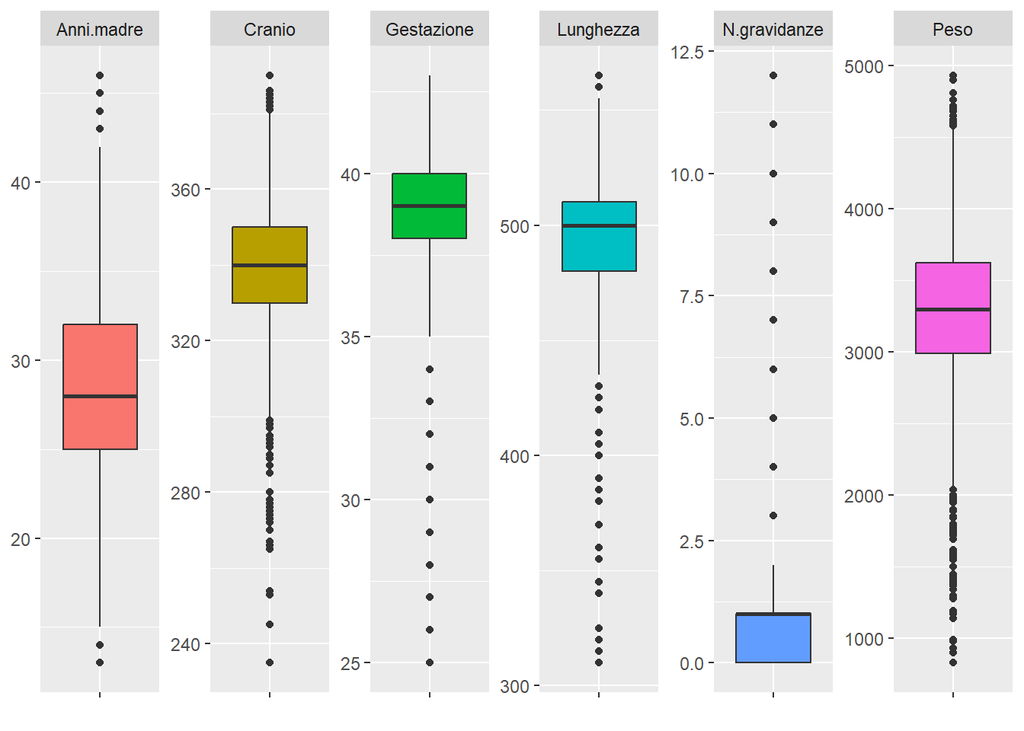

```r
boxplot_data_indici
```

#### Di seguito alcune considerazioni qualitative fatte basandomi sulla tabella delle statistiche descrittive delle variabili numeriche e sulla forma della distribuzione dei dati numerici.

#### -Cranio: valgono le stesse considerazioni fatte per la variabile lunghezza.

```r
shapiro_data_indici = sapply(data_indici, function(x) {
  shapiro.test(x)$p.value})

print(shapiro_data_indici)
```

```
##   Anni.madre N.gravidanze   Gestazione         Peso    Lunghezza       Cranio
## 1.476818e-07 9.334544e-54 2.729049e-45 3.378772e-22 3.313357e-36 1.295808e-24
```

#### Eseguo un test di normalità per validare se effettivamente le mie considerazioni trovano un riscontro quantitativo

#### Dallo shapiro test le variabili numeriche non appaiono distribuite normalmente. Prendo atto dei risultati del test di normalità e proseguo con l’analisi delle variabili categoriali.

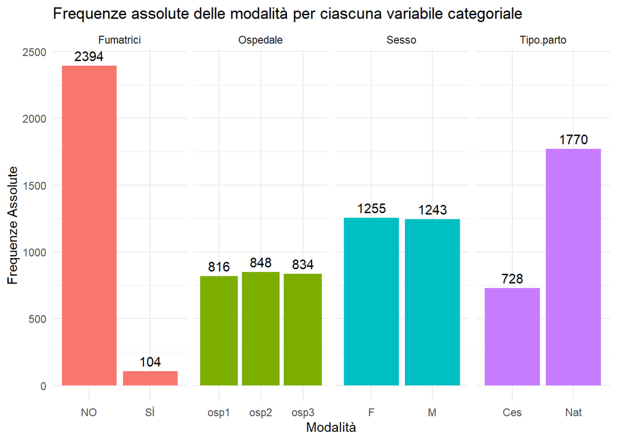

```r
# Creo un sottonsieme del dataset filtrato per calcolare le frequenze delle variabili categoriali

data_fattori = dati_filtrati %>%
  select_if(is.factor)

frequenze_assolute = data_fattori %>%
  pivot_longer(everything(), names_to = "variabile", values_to = "modalità") %>%
  count(variabile, modalità)

frequenze_relative = data_fattori %>%
  pivot_longer(everything(), names_to = "variabile", values_to = "modalità") %>%
  count(variabile, modalità) %>%
  group_by(variabile) %>%
  mutate(frequenze_relative = (n / sum(n)*100)) %>%
  ungroup()

grafico_frequenze_assolute =
  ggplot(frequenze_assolute, aes(x = modalità, y = n, fill = variabile)) +
  geom_bar(stat = "identity", position = "dodge") +
  geom_text(aes(label = n), vjust = -0.5, position = position_dodge(width = 0.9)) +
  facet_wrap(~ variabile, scales = "free_x", nrow = 1) +
  theme_minimal() +
  labs(x = "Modalità", y = "Frequenze Assolute",
       title = "Frequenze assolute delle modalità per ciascuna variabile categoriale") +
  theme(legend.position = "none")


grafico_frequenze_relative =
  ggplot(frequenze_relative, aes(x = modalità, y = frequenze_relative, fill = variabile)) +
  geom_bar(stat = "identity", position = "dodge") +
  geom_text(aes(label = sprintf("%.1f%%",frequenze_relative )),
            vjust = -0.5, position = position_dodge(width = 0.5)) +
  facet_wrap(~ variabile, scales = "free_x",nrow = 1) +
  labs(x = "Modalità", y = "Frequenza Relativa",
       title = "Frequenze relative delle modalità per ciascuna variabile categoriale") +
  theme_minimal() +
  theme(legend.position = "none")

grafico_frequenze_assolute
```

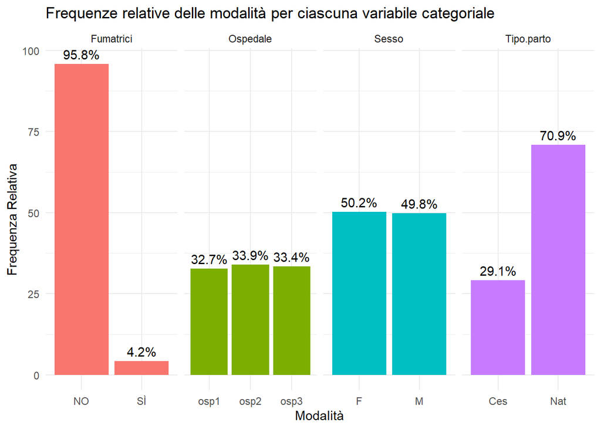

```r
grafico_frequenze_relative
```

#### Dall’analisi delle frequenze assolute si può osservare che:

#### -circa il 95% delle mamme non sono fumatrici.

#### -il campionamento è stato effettuato su 3 ospedali rappresentati in ugual misura.

#### -il numero dei nati maschi è circa uguale al numero delle femmine.

#### -in circa il 30% dei parti è stato praticato il cesareo.

## 4- Saggia l’ipotesi che la media del peso e della lunghezza di questo campione di neonati siano significativamente uguali a quelle della popolazione

```r
# https://www.who.int/tools/child-growth-standards/standards/weight-for-age

t.test(data_indici$Peso,
       mu = 3289,
       conf.level = 0.95,
       alternative = "two.sided",
       paired = FALSE)
```

```
##
##  One Sample t-test
##
## data:  data_indici$Peso
## t = -0.45827, df = 2497, p-value = 0.6468
## alternative hypothesis: true mean is not equal to 3289
## 95 percent confidence interval:
##  3263.577 3304.791
## sample estimates:
## mean of x
##  3284.184
```

#### La media del peso del campione non è significativamente diversa da quella della popolazione.

```r
 # https://www.who.int/tools/child-growth-standards/standards/length-height-for-age

t.test(data_indici$Lunghezza,
       mu = 495,
       conf.level = 0.95,
       alternative = "two.sided",
       paired = FALSE)
```

```
##
##  One Sample t-test
##
## data:  data_indici$Lunghezza
## t = -0.57754, df = 2497, p-value = 0.5636
## alternative hypothesis: true mean is not equal to 495
## 95 percent confidence interval:
##  493.6628 495.7287
## sample estimates:
## mean of x
##  494.6958
```

#### La media della lunghezza del campione non è significativamente diversa da quella della popolazione.

## 5-Per le stesse variabili, o per altre per le quali ha senso farlo, verifica differenze significative tra i due sessi.

#### Inizio analizzando se ci sono differenze significative tra i due sessi per quanto riguarda le variabili numeriche.

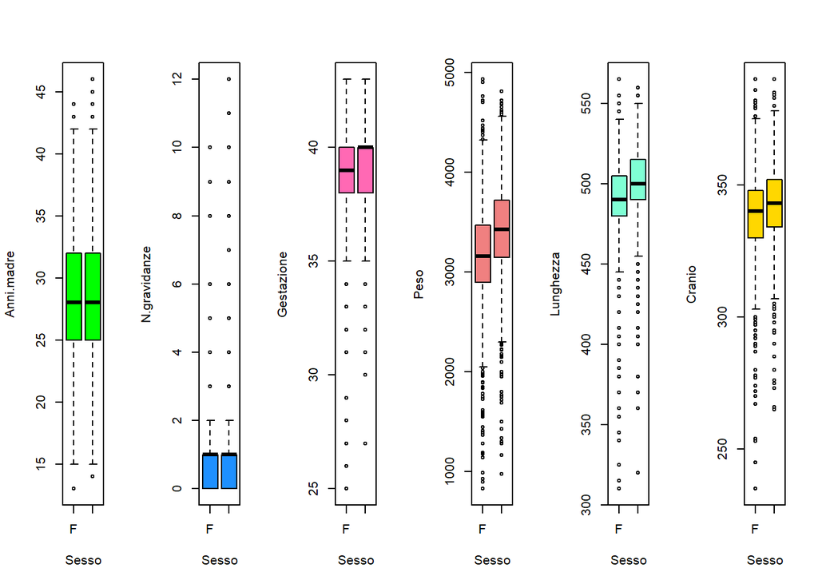

```r
par(mfrow =c(1,6))

boxplot(Anni.madre~Sesso,col="green")
boxplot(N.gravidanze~Sesso,col="dodgerblue")
boxplot(Gestazione~Sesso,col="hotpink")
boxplot(Peso~Sesso,col="lightcoral")
boxplot(Lunghezza~Sesso,col="aquamarine")
boxplot(Cranio~Sesso,col="gold")
```

```r
differenze_sesso_t_test = sapply(data_indici, function(x) {
  t.test(x ~ Sesso)$p.value})

print(differenze_sesso_t_test)
```

```
##   Anni.madre N.gravidanze   Gestazione         Peso    Lunghezza       Cranio
## 6.366427e-01 2.129632e-01 2.095855e-11 7.275684e-33 2.232328e-21 1.414019e-13
```

#### -Anni-madre non ci sono differenze significative tra i due sessi.

#### -N.gravidanze non ci sono differenze significative tra i due sessi.

#### -Gestazione ci sono differenze significative tra i due sessi.

#### -Peso ci sono differenze significative tra i due sessi.

#### -Lunghezza ci sono differenze significative tra i due sessi.

#### -Cranio ci sono differenze significative tra i due sessi.

### Procedo con l’analisi delle differenze tra i due sessi per quanto rigurda le variabili categoriali.

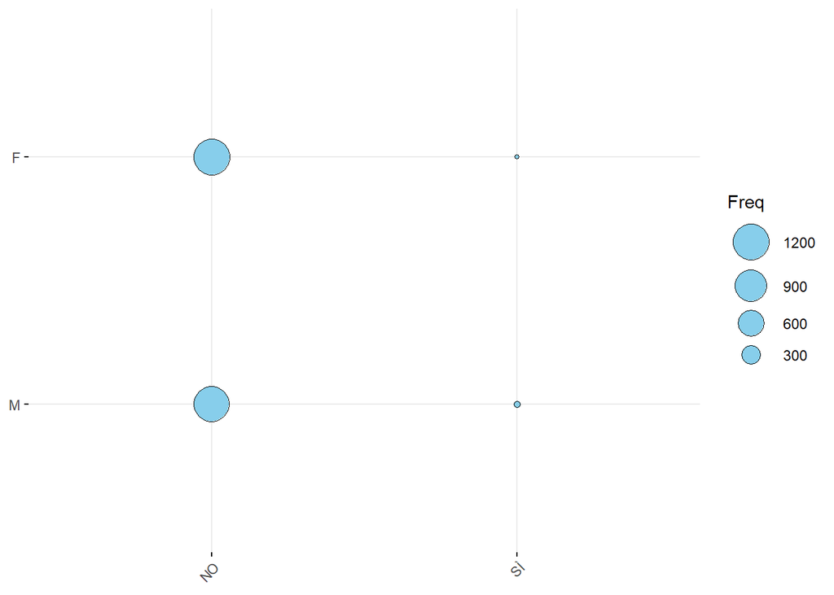

```r
tabella_fumatrici_sesso = table(Fumatrici,Sesso)
chisq_test_fumatrici_sesso = chisq.test(table(Fumatrici,Sesso))

ggballoonplot(data = as.data.frame(tabella_fumatrici_sesso),
              fill="skyblue")
```

```r
tabella_fumatrici_sesso
```

```
##          Sesso
## Fumatrici    F    M
##        NO 1206 1188
##        SÌ   49   55
```

```r
chisq_test_fumatrici_sesso
```

```
##
##  Pearson's Chi-squared test with Yates' continuity correction
##
## data:  table(Fumatrici, Sesso)
## X-squared = 0.30346, df = 1, p-value = 0.5817
```

#### Non si rifiuta l’ipotesi nulla. Non ci sono differenze significative tra i due sessi per la variabile categoriale fumatrici

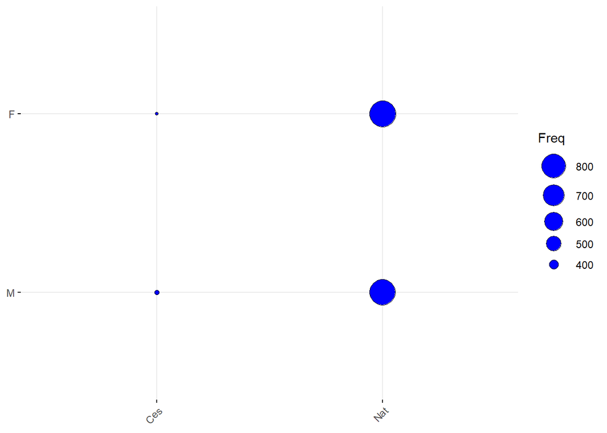

```r
tabella_tipoparto_sesso = table(Tipo.parto,Sesso)
chisq_test_tipoparto_sesso = chisq.test(table(Tipo.parto,Sesso))

ggballoonplot(data = as.data.frame(tabella_tipoparto_sesso),
              fill="blue")
```

```r
tabella_tipoparto_sesso
```

```
##           Sesso
## Tipo.parto   F   M
##        Ces 363 365
##        Nat 892 878
```

```r
chisq_test_tipoparto_sesso
```

```
##
##  Pearson's Chi-squared test with Yates' continuity correction
##
## data:  table(Tipo.parto, Sesso)
## X-squared = 0.039209, df = 1, p-value = 0.843
```

#### Non si rifiuta l’ipotesi nulla. Non ci sono differenze significative tra i due sessi per la variabile categoriale tipo_parto

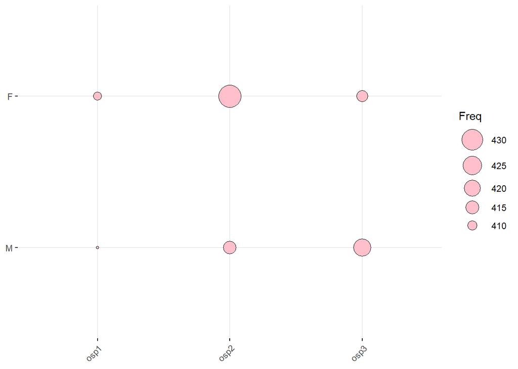

```r
tabella_ospedale_sesso = table(Ospedale,Sesso)
chisq_test_ospedale_sesso = chisq.test(table(Ospedale,Sesso))

ggballoonplot(data = as.data.frame(tabella_ospedale_sesso),
              fill="pink")
```

```r
tabella_ospedale_sesso
```

```
##         Sesso
## Ospedale   F   M
##     osp1 409 407
##     osp2 434 414
##     osp3 412 422
```

```r
chisq_test_ospedale_sesso
```

```
##
##  Pearson's Chi-squared test
##
## data:  table(Ospedale, Sesso)
## X-squared = 0.53887, df = 2, p-value = 0.7638
```

#### Non si rifiuta l’ipotesi nulla. Non ci sono differenze significative tra i due sessi per la variabile categoriale ospedale

## 6- Si vocifera che in alcuni ospedali si facciano più parti cesarei, sai verificare questa ipotesi?

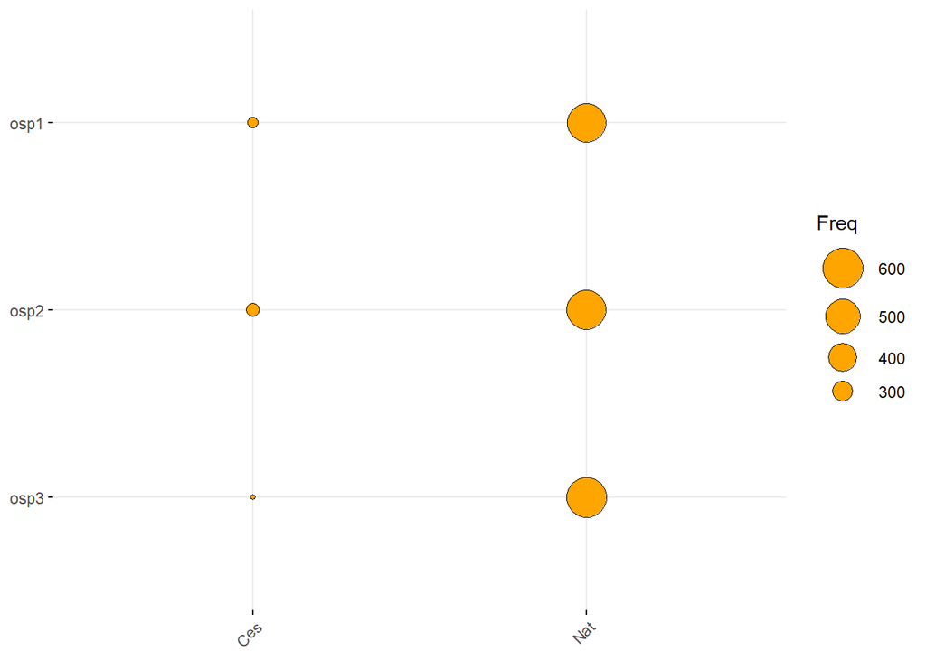

```r
#H0 Le variabili categoriali sono indipendenti
#H1 Le variabili categoriali non sono indipendenti

tabella_ospedali_tipo_parto = table(Tipo.parto,Ospedale)
chisq_test_tipo_parto = chisq.test(table(Tipo.parto,Ospedale))

ggballoonplot(data = as.data.frame(tabella_ospedali_tipo_parto),
              fill="orange")
```

```r
tabella_ospedali_tipo_parto
```

```
##           Ospedale
## Tipo.parto osp1 osp2 osp3
##        Ces  242  254  232
##        Nat  574  594  602
```

```r
chisq_test_tipo_parto
```

```
##
##  Pearson's Chi-squared test
##
## data:  table(Tipo.parto, Ospedale)
## X-squared = 1.083, df = 2, p-value = 0.5819
```

#### Dal valore del p-value non si rifiuta l’ipotesi nulla.

#### Le variabili sono indipendenti. Il numero di parti cesarei è indipendente dall’ospedale.

#Analisi multidimensionale

## 1-Ricordati qual è l’obbiettivo dello studio e indaga le relazioni a due a due, soprattutto con la variabile risposta

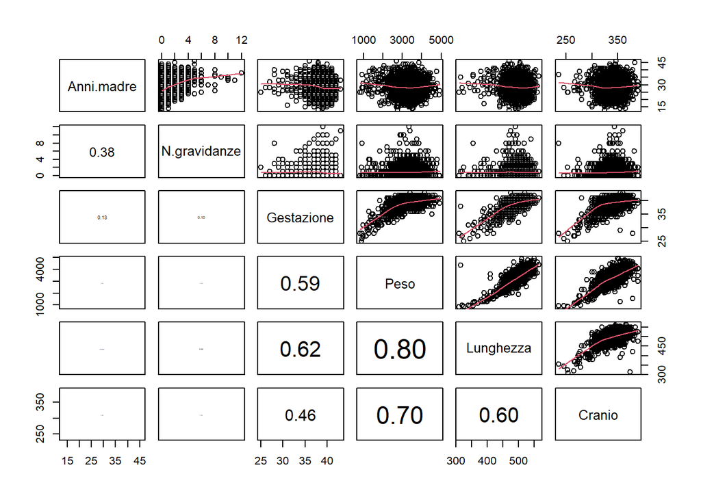

```r
panel.cor <- function(x, y, digits = 2, prefix = "", cex.cor, ...)
{
    par(usr = c(0, 1, 0, 1))
    r <- abs(cor(x, y))
    txt <- format(c(r, 0.123456789), digits = digits)[1]
    txt <- paste0(prefix, txt)
    if(missing(cex.cor)) cex.cor <- 0.8/strwidth(txt)
    text(0.5, 0.5, txt, cex = cex.cor * r)
}

pairs(data_indici,upper.panel = panel.smooth, lower.panel = panel.cor)
```

#### Da una prima analisi si osserva una forte correlazione lineare tra la variabili lunghezza e cranio con la variabile risposta peso.

#### Dall’analisi dell’andamento del grafico, le variabili gestazione e peso sembrano correlate con una relazione non lineare.

#### Le variabili anni.madre e N.gravidanze mostrano una correlazione quasi nulla con la variabile peso

#### Per le variabili numeriche per indagare le relazioni tra le variabili utilizzo la matrice di correlazione in modo da avere un riscontro numerico da confrontare con i grafici precedenti.

```r
matrice_correlazione = round(cor(data_indici),2)
print (matrice_correlazione)
```

```
##              Anni.madre N.gravidanze Gestazione  Peso Lunghezza Cranio
## Anni.madre         1.00         0.38      -0.13 -0.02     -0.06   0.02
## N.gravidanze       0.38         1.00      -0.10  0.00     -0.06   0.04
## Gestazione        -0.13        -0.10       1.00  0.59      0.62   0.46
## Peso              -0.02         0.00       0.59  1.00      0.80   0.70
## Lunghezza         -0.06        -0.06       0.62  0.80      1.00   0.60
## Cranio             0.02         0.04       0.46  0.70      0.60   1.00
```

#### Per indagare le relazioni tra le modalità delle variabili categoriali e la variabile risposta utilizziamo i boxplot ed il t-test.

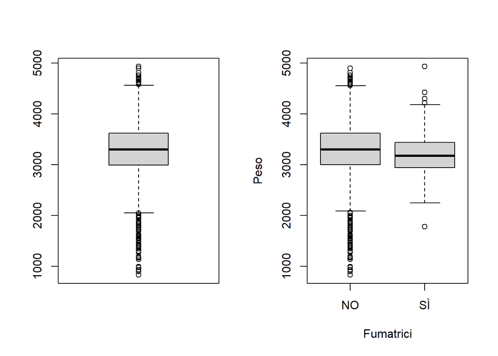

```r
par(mfrow=c(1,2))
boxplot(Peso)
boxplot(Peso~Fumatrici)
```

```r
t.test(Peso~Fumatrici)
```

```
##
##  Welch Two Sample t-test
##
## data:  Peso by Fumatrici
## t = 1.0362, df = 114.12, p-value = 0.3023
## alternative hypothesis: true difference in means between group NO and group SÌ is not equal to 0
## 95 percent confidence interval:
##  -45.5076 145.3399
## sample estimates:
## mean in group NO mean in group SÌ
##         3286.262         3236.346
```

#### dal p-value le differenze tra le medie non sono significativamente diverse da zero.

#### non ci sono relazioni significative tra le modalità della variabile categoriale fumatrice e la variabile risposta peso.

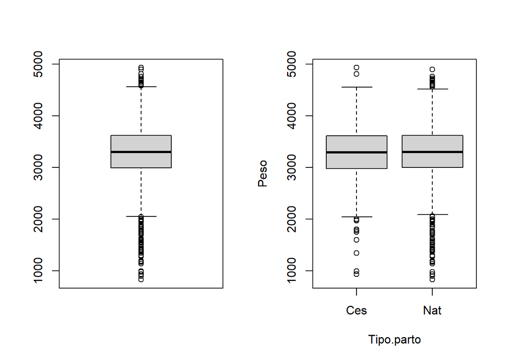

```r
par(mfrow=c(1,2))
boxplot(Peso)
boxplot(Peso~Tipo.parto)
```

```r
t.test(Peso~Tipo.parto)
```

```
##
##  Welch Two Sample t-test
##
## data:  Peso by Tipo.parto
## t = -0.13626, df = 1494.4, p-value = 0.8916
## alternative hypothesis: true difference in means between group Ces and group Nat is not equal to 0
## 95 percent confidence interval:
##  -46.44246  40.40931
## sample estimates:
## mean in group Ces mean in group Nat
##          3282.047          3285.063
```

#### Dal p-value le differenze tra le medie non sono significativamente diverse da zero.

#### Non ci sono relazioni significative tra le modalità della variabile categoriale tipo.parto e la variabile risposta peso.

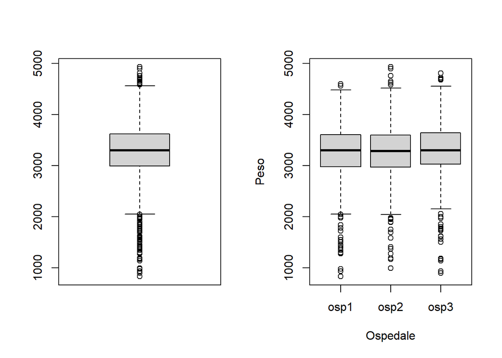

```r
par(mfrow=c(1,2))
boxplot(Peso)
boxplot(Peso~Ospedale)
```

```r
mean(Peso[Ospedale=="osp1"])
```

```
## [1] 3270.266
```

```r
mean(Peso[Ospedale=="osp2"])
```

```
## [1] 3270.507
```

```r
mean(Peso[Ospedale=="osp3"])
```

```
## [1] 3311.709
```

```r
pairwise.t.test(Peso,Ospedale,
                paired = F,
                pool.sd = T,
                p.adjust.method = "bonferroni")
```

```
##
##  Pairwise comparisons using t tests with pooled SD
##
## data:  Peso and Ospedale
##
##      osp1 osp2
## osp2 1.00 -
## osp3 0.33 0.32
##
## P value adjustment method: bonferroni
```

#### Dal p-value le differenze tra le medie non sono significativamente diverse da zero.

#### Non ci sono relazioni significative tra le modalità della variabile categoriale ospedale e la variabile risposta peso.

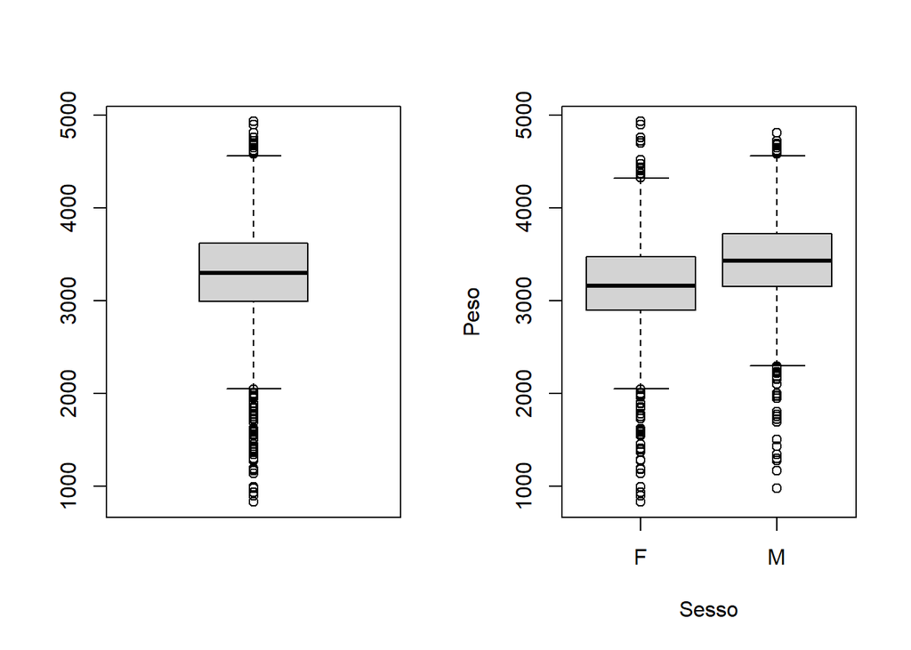

```r
par(mfrow=c(1,2))
boxplot(Peso)
boxplot(Peso~Sesso)
```

```r
t.test(Peso~Sesso)
```

```
##
##  Welch Two Sample t-test
##
## data:  Peso by Sesso
## t = -12.115, df = 2488.7, p-value < 2.2e-16
## alternative hypothesis: true difference in means between group F and group M is not equal to 0
## 95 percent confidence interval:
##  -287.4841 -207.3844
## sample estimates:
## mean in group F mean in group M
##        3161.061        3408.496
```

### Le differenze tra le medie sono significativamente diverse da zero

### Mi aspetto un beta di regressione significativo per la variabile categoriale sesso

### Posso utilizzare la variabile sesso come variabile di controllo

```r
mod1 = lm(Peso ~ ., data=dati_filtrati)
summary(mod1)
```

```
##
## Call:
## lm(formula = Peso ~ ., data = dati_filtrati)
##
## Residuals:
##      Min       1Q   Median       3Q      Max
## -1123.26  -181.53   -14.45   161.05  2611.89
##
## Coefficients:
##                 Estimate Std. Error t value Pr(>|t|)
## (Intercept)   -6735.7960   141.4790 -47.610  < 2e-16 ***
## Anni.madre        0.8018     1.1467   0.699   0.4845
## N.gravidanze     11.3812     4.6686   2.438   0.0148 *
## FumatriciSÌ     -30.2741    27.5492  -1.099   0.2719
## Gestazione       32.5773     3.8208   8.526  < 2e-16 ***
## Lunghezza        10.2922     0.3009  34.207  < 2e-16 ***
## Cranio           10.4722     0.4263  24.567  < 2e-16 ***
## Tipo.partoNat    29.6335    12.0905   2.451   0.0143 *
## Ospedaleosp2    -11.0912    13.4471  -0.825   0.4096
## Ospedaleosp3     28.2495    13.5054   2.092   0.0366 *
## SessoM           77.5723    11.1865   6.934 5.18e-12 ***
## ---
## Signif. codes:  0 '***' 0.001 '**' 0.01 '*' 0.05 '.' 0.1 ' ' 1
##
## Residual standard error: 274 on 2487 degrees of freedom
## Multiple R-squared:  0.7289, Adjusted R-squared:  0.7278
## F-statistic: 668.7 on 10 and 2487 DF,  p-value: < 2.2e-16
```

#### Dato che dal grafico avevo notato una relazione non lineare tra gestazione e peso provo a considerare questa interazione all’interno del modello.

```r
mod2 = update(mod1, ~.+I(Gestazione^2), data=dati_filtrati)

summary(mod2)
```

```
##
## Call:
## lm(formula = Peso ~ Anni.madre + N.gravidanze + Fumatrici + Gestazione +
##     Lunghezza + Cranio + Tipo.parto + Ospedale + Sesso + I(Gestazione^2),
##     data = dati_filtrati)
##
## Residuals:
##      Min       1Q   Median       3Q      Max
## -1148.19  -180.38   -11.38   163.10  2633.32
##
## Coefficients:
##                   Estimate Std. Error t value Pr(>|t|)
## (Intercept)     -4829.2398   897.7235  -5.379 8.17e-08 ***
## Anni.madre          0.8817     1.1465   0.769   0.4419
## N.gravidanze       11.3475     4.6652   2.432   0.0151 *
## FumatriciSÌ       -29.1125    27.5344  -1.057   0.2905
## Gestazione        -73.9808    49.6949  -1.489   0.1367
## Lunghezza          10.3897     0.3041  34.170  < 2e-16 ***
## Cranio             10.5626     0.4280  24.677  < 2e-16 ***
## Tipo.partoNat      29.1905    12.0835   2.416   0.0158 *
## Ospedaleosp2      -10.3404    13.4418  -0.769   0.4418
## Ospedaleosp3       27.8907    13.4966   2.066   0.0389 *
## SessoM             75.4868    11.2204   6.728 2.13e-11 ***
## I(Gestazione^2)     1.4229     0.6616   2.151   0.0316 *
## ---
## Signif. codes:  0 '***' 0.001 '**' 0.01 '*' 0.05 '.' 0.1 ' ' 1
##
## Residual standard error: 273.8 on 2486 degrees of freedom
## Multiple R-squared:  0.7294, Adjusted R-squared:  0.7282
## F-statistic: 609.2 on 11 and 2486 DF,  p-value: < 2.2e-16
```

#### La variabile gestazione, che era molto significativa nel mod1, considerando una correlazione quadratica diventa non significativa. In aggiunta il termine quadratico risulta poco significativo; decido quindi di non includere il termine quadratico nel modello.

```r
#elimino la variabile anni madre dato che risulta poco significativa
mod3 = update(mod1,~. -Anni.madre,data=dati_filtrati)
summary(mod3)
```

```
##
## Call:
## lm(formula = Peso ~ N.gravidanze + Fumatrici + Gestazione + Lunghezza +
##     Cranio + Tipo.parto + Ospedale + Sesso, data = dati_filtrati)
##
## Residuals:
##      Min       1Q   Median       3Q      Max
## -1113.82  -180.30   -16.22   160.66  2616.32
##
## Coefficients:
##                 Estimate Std. Error t value Pr(>|t|)
## (Intercept)   -6708.6189   136.0211 -49.320  < 2e-16 ***
## N.gravidanze     12.5833     4.3400   2.899  0.00377 **
## FumatriciSÌ     -30.4268    27.5455  -1.105  0.26944
## Gestazione       32.2996     3.7997   8.501  < 2e-16 ***
## Lunghezza        10.2916     0.3008  34.209  < 2e-16 ***
## Cranio           10.4874     0.4257  24.638  < 2e-16 ***
## Tipo.partoNat    29.6654    12.0892   2.454  0.01420 *
## Ospedaleosp2    -10.9509    13.4442  -0.815  0.41541
## Ospedaleosp3     28.5171    13.4986   2.113  0.03474 *
## SessoM           77.6452    11.1849   6.942 4.91e-12 ***
## ---
## Signif. codes:  0 '***' 0.001 '**' 0.01 '*' 0.05 '.' 0.1 ' ' 1
##
## Residual standard error: 274 on 2488 degrees of freedom
## Multiple R-squared:  0.7288, Adjusted R-squared:  0.7279
## F-statistic: 743.1 on 9 and 2488 DF,  p-value: < 2.2e-16
```

#### Eliminando la variabile numerica anni.madre dal modello, la diminuzione del valore di R-squared risulta trascurabile.

```r
#elimino la variabile fumatrici dato che risulta poco significativa

mod4 = update(mod3,~. -Fumatrici,data=dati_filtrati)
summary(mod4)
```

```
##
## Call:
## lm(formula = Peso ~ N.gravidanze + Gestazione + Lunghezza + Cranio +
##     Tipo.parto + Ospedale + Sesso, data = dati_filtrati)
##
## Residuals:
##      Min       1Q   Median       3Q      Max
## -1113.07  -181.71   -16.66   161.08  2619.57
##
## Coefficients:
##                 Estimate Std. Error t value Pr(>|t|)
## (Intercept)   -6707.9252   136.0257 -49.314  < 2e-16 ***
## N.gravidanze     12.3360     4.3344   2.846  0.00446 **
## Gestazione       32.0386     3.7925   8.448  < 2e-16 ***
## Lunghezza        10.3059     0.3006  34.286  < 2e-16 ***
## Cranio           10.4920     0.4257  24.648  < 2e-16 ***
## Tipo.partoNat    29.4080    12.0875   2.433  0.01505 *
## Ospedaleosp2    -10.8939    13.4447  -0.810  0.41786
## Ospedaleosp3     28.7917    13.4969   2.133  0.03301 *
## SessoM           77.4657    11.1842   6.926 5.48e-12 ***
## ---
## Signif. codes:  0 '***' 0.001 '**' 0.01 '*' 0.05 '.' 0.1 ' ' 1
##
## Residual standard error: 274 on 2489 degrees of freedom
## Multiple R-squared:  0.7287, Adjusted R-squared:  0.7278
## F-statistic: 835.7 on 8 and 2489 DF,  p-value: < 2.2e-16
```

#### Eliminando la variabile categoriale fumatrici dal modello, la diminuzione del valore di R-squared risulta trascurabile.

```r
mod5 = update(mod4,~. -Ospedale,data=dati_filtrati)
summary(mod5)
```

```
##
## Call:
## lm(formula = Peso ~ N.gravidanze + Gestazione + Lunghezza + Cranio +
##     Tipo.parto + Sesso, data = dati_filtrati)
##
## Residuals:
##      Min       1Q   Median       3Q      Max
## -1129.14  -181.97   -16.26   160.95  2638.18
##
## Coefficients:
##                 Estimate Std. Error t value Pr(>|t|)
## (Intercept)   -6708.0171   136.0715 -49.298  < 2e-16 ***
## N.gravidanze     12.7356     4.3385   2.935  0.00336 **
## Gestazione       32.3253     3.7969   8.514  < 2e-16 ***
## Lunghezza        10.2833     0.3009  34.177  < 2e-16 ***
## Cranio           10.5063     0.4263  24.648  < 2e-16 ***
## Tipo.partoNat    30.1601    12.1027   2.492  0.01277 *
## SessoM           77.9171    11.1994   6.957 4.42e-12 ***
## ---
## Signif. codes:  0 '***' 0.001 '**' 0.01 '*' 0.05 '.' 0.1 ' ' 1
##
## Residual standard error: 274.4 on 2491 degrees of freedom
## Multiple R-squared:  0.7277, Adjusted R-squared:  0.727
## F-statistic:  1109 on 6 and 2491 DF,  p-value: < 2.2e-16
```

#### Eliminando la variabile categoriale ospedale dal modello, la diminuzione del valore di R-squared risulta trascurabile.

```r
mod6 = update(mod5,~. -Tipo.parto,data=dati_filtrati)
summary(mod6)
```

```
##
## Call:
## lm(formula = Peso ~ N.gravidanze + Gestazione + Lunghezza + Cranio +
##     Sesso, data = dati_filtrati)
##
## Residuals:
##      Min       1Q   Median       3Q      Max
## -1149.37  -180.98   -15.57   163.69  2639.09
##
## Coefficients:
##                Estimate Std. Error t value Pr(>|t|)
## (Intercept)  -6681.7251   135.8036 -49.201  < 2e-16 ***
## N.gravidanze    12.4554     4.3416   2.869  0.00415 **
## Gestazione      32.3827     3.8008   8.520  < 2e-16 ***
## Lunghezza       10.2455     0.3008  34.059  < 2e-16 ***
## Cranio          10.5410     0.4265  24.717  < 2e-16 ***
## SessoM          77.9807    11.2111   6.956 4.47e-12 ***
## ---
## Signif. codes:  0 '***' 0.001 '**' 0.01 '*' 0.05 '.' 0.1 ' ' 1
##
## Residual standard error: 274.7 on 2492 degrees of freedom
## Multiple R-squared:  0.727,  Adjusted R-squared:  0.7265
## F-statistic:  1327 on 5 and 2492 DF,  p-value: < 2.2e-16
```

#### Eliminando la variabile categoriale tipo.parto dal modello, la diminuzione del valore di R-squared risulta trascurabile.

#### Procedo con l’eliminazione del parametro N.gravidanza consapevole che questa variabile presenta un livello di significagtività non trascurabile.

```r
mod7 = update(mod6,~. -N.gravidanze,data=dati_filtrati)
summary(mod7)
```

```
##
## Call:
## lm(formula = Peso ~ Gestazione + Lunghezza + Cranio + Sesso,
##     data = dati_filtrati)
##
## Residuals:
##     Min      1Q  Median      3Q     Max
## -1138.1  -184.4   -17.4   163.3  2626.7
##
## Coefficients:
##               Estimate Std. Error t value Pr(>|t|)
## (Intercept) -6651.6732   135.5952 -49.055  < 2e-16 ***
## Gestazione     31.3262     3.7884   8.269  < 2e-16 ***
## Lunghezza      10.2024     0.3009  33.909  < 2e-16 ***
## Cranio         10.6706     0.4247  25.126  < 2e-16 ***
## SessoM         79.1027    11.2205   7.050 2.31e-12 ***
## ---
## Signif. codes:  0 '***' 0.001 '**' 0.01 '*' 0.05 '.' 0.1 ' ' 1
##
## Residual standard error: 275.1 on 2493 degrees of freedom
## Multiple R-squared:  0.7261, Adjusted R-squared:  0.7257
## F-statistic:  1652 on 4 and 2493 DF,  p-value: < 2.2e-16
```

```r
anova(mod7,mod6,mod5,mod4,mod3,mod2,mod1)
```

```
## Analysis of Variance Table
##
## Model 1: Peso ~ Gestazione + Lunghezza + Cranio + Sesso
## Model 2: Peso ~ N.gravidanze + Gestazione + Lunghezza + Cranio + Sesso
## Model 3: Peso ~ N.gravidanze + Gestazione + Lunghezza + Cranio + Tipo.parto +
##     Sesso
## Model 4: Peso ~ N.gravidanze + Gestazione + Lunghezza + Cranio + Tipo.parto +
##     Ospedale + Sesso
## Model 5: Peso ~ N.gravidanze + Fumatrici + Gestazione + Lunghezza + Cranio +
##     Tipo.parto + Ospedale + Sesso
## Model 6: Peso ~ Anni.madre + N.gravidanze + Fumatrici + Gestazione + Lunghezza +
##     Cranio + Tipo.parto + Ospedale + Sesso + I(Gestazione^2)
## Model 7: Peso ~ Anni.madre + N.gravidanze + Fumatrici + Gestazione + Lunghezza +
##     Cranio + Tipo.parto + Ospedale + Sesso
##   Res.Df       RSS Df Sum of Sq      F   Pr(>F)
## 1   2493 188663107
## 2   2492 188042054  1    621053 8.2831 0.004036 **
## 3   2491 187574428  1    467626 6.2368 0.012576 *
## 4   2489 186871503  2    702925 4.6875 0.009291 **
## 5   2488 186779904  1     91599 1.2217 0.269139
## 6   2486 186396411  2    383492 2.5574 0.077714 .
## 7   2487 186743194 -1   -346782 4.6251 0.031604 *
## ---
## Signif. codes:  0 '***' 0.001 '**' 0.01 '*' 0.05 '.' 0.1 ' ' 1
```

#### Dall’analisi della varianza il mod4 appre un buon compromesso per spiegare la varianza della variabile risposta. Analizzo i valori di r-squared e del BIC per decidere quale modello utilizzare.

```r
mod1_r_squared=summary(mod1)$adj.r.squared
mod2_r_squared=summary(mod2)$adj.r.squared
mod3_r_squared=summary(mod3)$adj.r.squared
mod4_r_squared=summary(mod4)$adj.r.squared
mod5_r_squared=summary(mod5)$adj.r.squared
mod6_r_squared=summary(mod6)$adj.r.squared
mod7_r_squared=summary(mod7)$adj.r.squared

r_squared_table = rbind(mod1_r_squared,mod2_r_squared,mod3_r_squared,mod4_r_squared,mod5_r_squared,mod6_r_squared,mod7_r_squared)

print(r_squared_table)
```

```
##                     [,1]
## mod1_r_squared 0.7278107
## mod2_r_squared 0.7282069
## mod3_r_squared 0.7278667
## mod4_r_squared 0.7278426
## mod5_r_squared 0.7270382
## mod6_r_squared 0.7264675
## mod7_r_squared 0.7256742
```

#### Dall’analisi dell’adj.r.squared i modelli spiegano pressochè la stessa variabilità.

#### A questo punto mi affido alla funzione BIC per scegliere a il modello.

```r
BIC(mod7,mod6,mod5,mod4,mod3,mod2,mod1)
```

```
##      df      BIC
## mod7  6 35194.06
## mod6  7 35193.65
## mod5  8 35195.25
## mod4 10 35201.52
## mod3 11 35208.12
## mod2 13 35218.63
## mod1 12 35215.45
```

#### Dall’analisi dei criteri di informazione i modelli mod7,mod6,mod5,mod4 e mod3 appaiono comparabili.

#### Dato che i risultati del BIC sono simili per questi modelli, scelgo il modello più semplice cioè il mod7.

```r
car::vif(mod7)
```

```
## Gestazione  Lunghezza     Cranio      Sesso
##   1.654101   2.070582   1.606316   1.038918
```

#### Non si osservano problemi di multi-collinearità.

#### Vado ad effettuare l’analisi dei residui del modello.

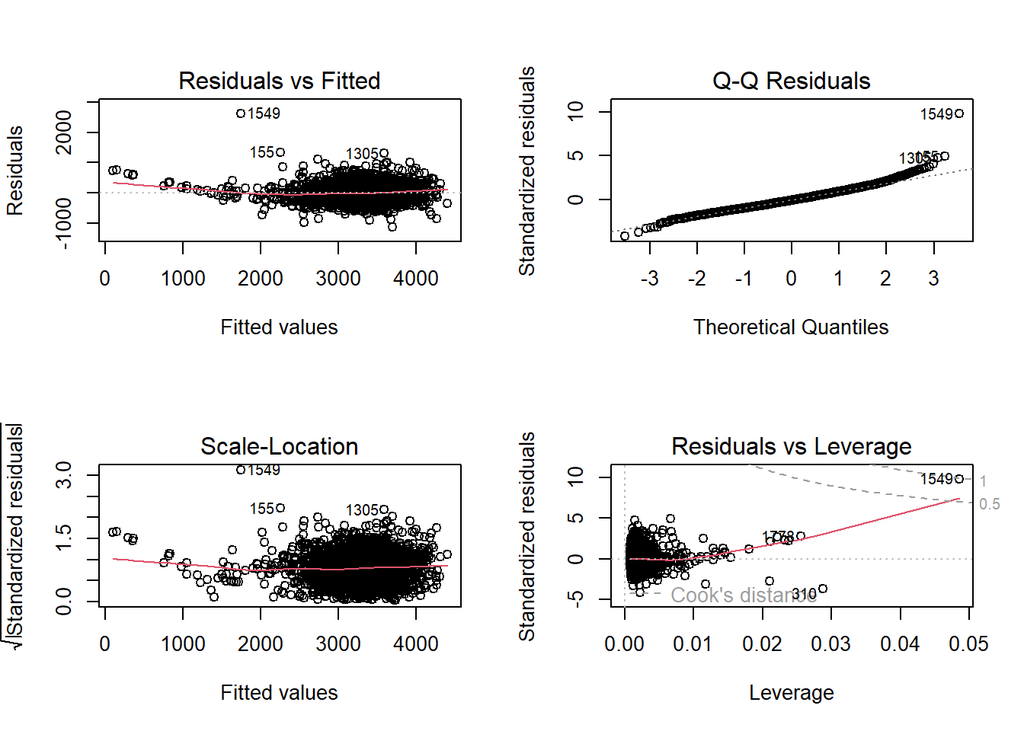

```r
par(mfrow=c(2,2))
plot(mod7)
```

```r
shapiro.test(residuals(mod7))
```

```
##
##  Shapiro-Wilk normality test
##
## data:  residuals(mod7)
## W = 0.97426, p-value < 2.2e-16
```

```r
lmtest::bptest(mod7)
```

```
##
##  studentized Breusch-Pagan test
##
## data:  mod7
## BP = 89.198, df = 4, p-value < 2.2e-16
```

```r
lmtest::dwtest(mod7)
```

```
##
##  Durbin-Watson test
##
## data:  mod7
## DW = 1.9553, p-value = 0.1318
## alternative hypothesis: true autocorrelation is greater than 0
```

#### Lo shapiro-test rifiuta l’ipotesi di normalità del modello.

#### Il test di Breusch-Pagan indica la presenza di eteroschedasticità.

#### Il test di Durbin-Watson indica l’assenza di autocorrelazione tra i residui.

#### Quindi i residui del modello non soddisfano i requisiti di distribuzione normale e varianza costante.

#### Dall’analisi del grafico Residual vs Fitted si osserva una leggera deviazione dalla media uguale a zero in prossimità dei fitted value fino a 1500.

#### Dall’analisi del grafico Q-Q Residual in prossimità dei quantili teorici pari a 3 si ha una deviazione dalla bisettrice. L’osservazione 1549 risulta molto distante dalla bisettrice.

#### Dall’analisi del grafico Residuals vs Leverage si nota come l’osservazione 1549 si trovi in corrispondenza della soglia di allarme con una distanza di cook vicina ad 1.

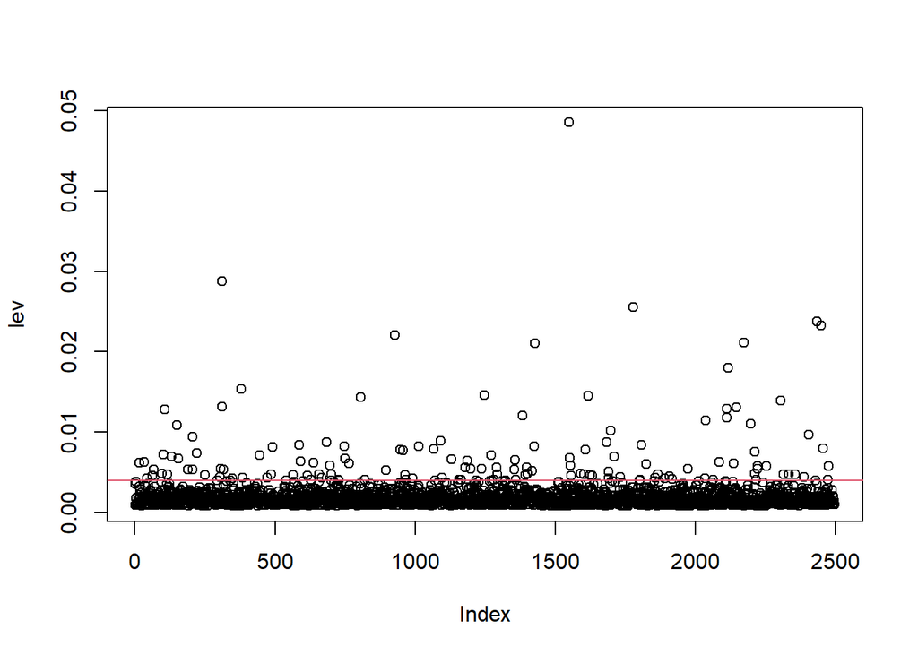

```r
#lavarage
n=nrow(data)
lev=hatvalues(mod7)
plot(lev)
p=sum(lev)
soglia=2*p/n
abline(h=soglia,col=2)
```

```r
#lev[lev>soglia]
```

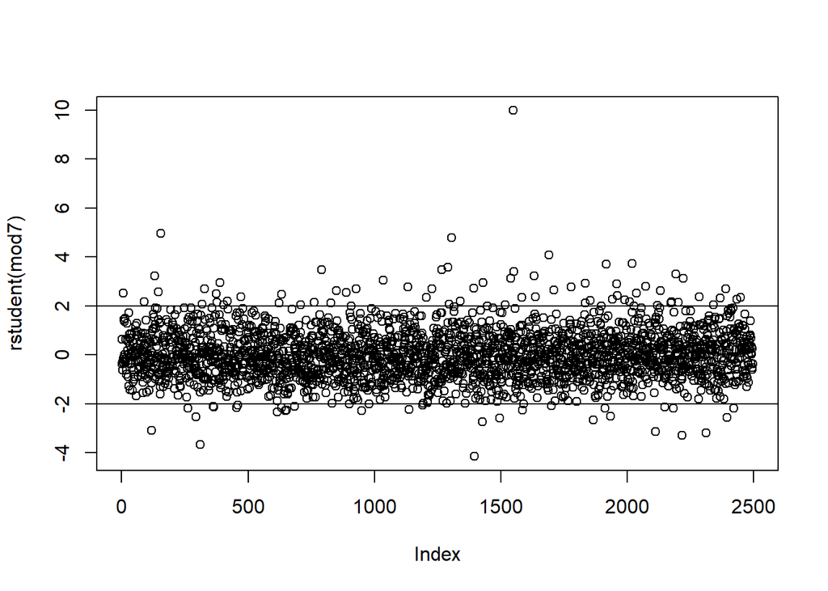

```r
#outlier
plot(rstudent(mod7))
abline(h=c(-2,2))
```

```r
car::outlierTest(mod7)
```

```
##      rstudent unadjusted p-value Bonferroni p
## 1549 9.980701         4.9791e-23   1.2438e-19
## 155  4.948947         7.9596e-07   1.9883e-03
## 1305 4.779033         1.8638e-06   4.6558e-03
```

#### L’analisi degli outlier mostra 3 valori tra i quali l’osservazione 1549 che avevo già attenzionato.

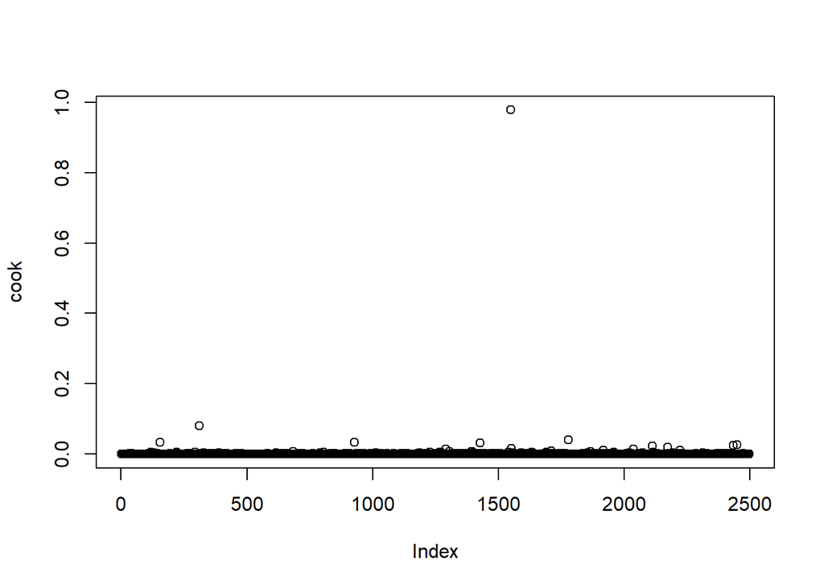

```r
#distanza di cook
cook=cooks.distance(mod7)
plot(cook)
```

```r
influent_point = which(cook >0.6)
print(influent_point)
```

```
## 1549
## 1549
```

#### L’osservazione potrebbe essere influente sul modello di regressione.

#### Decido di eliminare l’osservazione 1549 e creo un nuovo modello senza di essa.

```r
dati_no_outlier = dati_filtrati[-c(1549),]
```

```r
mod1a = lm(Peso ~ . , data=dati_no_outlier)
summary(mod1a)
```

```
##
## Call:
## lm(formula = Peso ~ ., data = dati_no_outlier)
##
## Residuals:
##      Min       1Q   Median       3Q      Max
## -1136.89  -181.06   -13.37   159.19  1407.16
##
## Coefficients:
##                 Estimate Std. Error t value Pr(>|t|)
## (Intercept)   -6727.9208   138.7620 -48.485  < 2e-16 ***
## Anni.madre        0.5356     1.1250   0.476  0.63403
## N.gravidanze     12.4605     4.5801   2.721  0.00656 **
## FumatriciSÌ     -27.3556    27.0213  -1.012  0.31146
## Gestazione       29.7564     3.7580   7.918 3.60e-15 ***
## Lunghezza        10.9308     0.3020  36.199  < 2e-16 ***
## Cranio            9.8623     0.4225  23.341  < 2e-16 ***
## Tipo.partoNat    29.5171    11.8581   2.489  0.01287 *
## Ospedaleosp2    -11.7248    13.1888  -0.889  0.37409
## Ospedaleosp3     25.1656    13.2495   1.899  0.05763 .
## SessoM           77.7578    10.9715   7.087 1.77e-12 ***
## ---
## Signif. codes:  0 '***' 0.001 '**' 0.01 '*' 0.05 '.' 0.1 ' ' 1
##
## Residual standard error: 268.8 on 2486 degrees of freedom
## Multiple R-squared:  0.7389, Adjusted R-squared:  0.7378
## F-statistic: 703.5 on 10 and 2486 DF,  p-value: < 2.2e-16
```

```r
mod2a = update(mod1a,~. -Anni.madre, data=dati_no_outlier)
summary(mod2a)
```

```
##
## Call:
## lm(formula = Peso ~ N.gravidanze + Fumatrici + Gestazione + Lunghezza +
##     Cranio + Tipo.parto + Ospedale + Sesso, data = dati_no_outlier)
##
## Residuals:
##      Min       1Q   Median       3Q      Max
## -1130.60  -181.05   -13.95   160.22  1408.53
##
## Coefficients:
##                 Estimate Std. Error t value Pr(>|t|)
## (Intercept)   -6709.7667   133.3999 -50.298  < 2e-16 ***
## N.gravidanze     13.2644     4.2569   3.116  0.00185 **
## FumatriciSÌ     -27.4542    27.0163  -1.016  0.30963
## Gestazione       29.5678     3.7365   7.913 3.74e-15 ***
## Lunghezza        10.9311     0.3019  36.205  < 2e-16 ***
## Cranio            9.8718     0.4220  23.393  < 2e-16 ***
## Tipo.partoNat    29.5382    11.8562   2.491  0.01279 *
## Ospedaleosp2    -11.6319    13.1853  -0.882  0.37776
## Ospedaleosp3     25.3407    13.2423   1.914  0.05578 .
## SessoM           77.8067    10.9693   7.093 1.70e-12 ***
## ---
## Signif. codes:  0 '***' 0.001 '**' 0.01 '*' 0.05 '.' 0.1 ' ' 1
##
## Residual standard error: 268.7 on 2487 degrees of freedom
## Multiple R-squared:  0.7389, Adjusted R-squared:  0.7379
## F-statistic: 781.8 on 9 and 2487 DF,  p-value: < 2.2e-16
```

```r
mod3a = update(mod2a,~. -Fumatrici, data=dati_no_outlier)
summary(mod3a)
```

```
##
## Call:
## lm(formula = Peso ~ N.gravidanze + Gestazione + Lunghezza + Cranio +
##     Tipo.parto + Ospedale + Sesso, data = dati_no_outlier)
##
## Residuals:
##     Min      1Q  Median      3Q     Max
## -1129.9  -181.4   -14.7   160.1  1410.2
##
## Coefficients:
##                 Estimate Std. Error t value Pr(>|t|)
## (Intercept)   -6709.1422   133.3993 -50.294  < 2e-16 ***
## N.gravidanze     13.0420     4.2513   3.068  0.00218 **
## Gestazione       29.3292     3.7291   7.865 5.46e-15 ***
## Lunghezza        10.9447     0.3016  36.286  < 2e-16 ***
## Cranio            9.8752     0.4220  23.402  < 2e-16 ***
## Tipo.partoNat    29.3059    11.8541   2.472  0.01349 *
## Ospedaleosp2    -11.5812    13.1853  -0.878  0.37984
## Ospedaleosp3     25.5849    13.2402   1.932  0.05343 .
## SessoM           77.6449    10.9683   7.079 1.88e-12 ***
## ---
## Signif. codes:  0 '***' 0.001 '**' 0.01 '*' 0.05 '.' 0.1 ' ' 1
##
## Residual standard error: 268.7 on 2488 degrees of freedom
## Multiple R-squared:  0.7387, Adjusted R-squared:  0.7379
## F-statistic: 879.4 on 8 and 2488 DF,  p-value: < 2.2e-16
```

```r
mod4a = update(mod3a,~. -Ospedale, data=dati_no_outlier)
summary(mod4a)
```

```
##
## Call:
## lm(formula = Peso ~ N.gravidanze + Gestazione + Lunghezza + Cranio +
##     Tipo.parto + Sesso, data = dati_no_outlier)
##
## Residuals:
##      Min       1Q   Median       3Q      Max
## -1145.56  -180.17   -16.93   159.24  1404.90
##
## Coefficients:
##                 Estimate Std. Error t value Pr(>|t|)
## (Intercept)   -6709.9817   133.4180 -50.293  < 2e-16 ***
## N.gravidanze     13.4232     4.2545   3.155  0.00162 **
## Gestazione       29.5780     3.7329   7.924 3.45e-15 ***
## Lunghezza        10.9273     0.3019  36.196  < 2e-16 ***
## Cranio            9.8850     0.4225  23.397  < 2e-16 ***
## Tipo.partoNat    29.9970    11.8667   2.528  0.01154 *
## SessoM           78.0743    10.9810   7.110 1.51e-12 ***
## ---
## Signif. codes:  0 '***' 0.001 '**' 0.01 '*' 0.05 '.' 0.1 ' ' 1
##
## Residual standard error: 269.1 on 2490 degrees of freedom
## Multiple R-squared:  0.7379, Adjusted R-squared:  0.7372
## F-statistic:  1168 on 6 and 2490 DF,  p-value: < 2.2e-16
```

```r
mod5a = update(mod4a,~. -Tipo.parto, data=dati_no_outlier)
summary(mod5a)
```

```
##
## Call:
## lm(formula = Peso ~ N.gravidanze + Gestazione + Lunghezza + Cranio +
##     Sesso, data = dati_no_outlier)
##
## Residuals:
##      Min       1Q   Median       3Q      Max
## -1165.68  -179.74   -12.42   162.92  1410.68
##
## Coefficients:
##                Estimate Std. Error t value Pr(>|t|)
## (Intercept)  -6683.8326   133.1602 -50.194  < 2e-16 ***
## N.gravidanze    13.1448     4.2576   3.087  0.00204 **
## Gestazione      29.6341     3.7369   7.930 3.27e-15 ***
## Lunghezza       10.8899     0.3019  36.077  < 2e-16 ***
## Cranio           9.9192     0.4227  23.465  < 2e-16 ***
## SessoM          78.1376    10.9929   7.108 1.53e-12 ***
## ---
## Signif. codes:  0 '***' 0.001 '**' 0.01 '*' 0.05 '.' 0.1 ' ' 1
##
## Residual standard error: 269.3 on 2491 degrees of freedom
## Multiple R-squared:  0.7372, Adjusted R-squared:  0.7367
## F-statistic:  1398 on 5 and 2491 DF,  p-value: < 2.2e-16
```

```r
mod6a = update(mod5a,~. -N.gravidanze, data=dati_no_outlier)
summary(mod6a)
```

```
##
## Call:
## lm(formula = Peso ~ Gestazione + Lunghezza + Cranio + Sesso,
##     data = dati_no_outlier)
##
## Residuals:
##      Min       1Q   Median       3Q      Max
## -1153.75  -182.01   -14.88   163.78  1391.18
##
## Coefficients:
##              Estimate Std. Error t value Pr(>|t|)
## (Intercept) -6652.115    132.990 -50.020  < 2e-16 ***
## Gestazione     28.533      3.726   7.657 2.69e-14 ***
## Lunghezza      10.841      0.302  35.903  < 2e-16 ***
## Cranio         10.059      0.421  23.893  < 2e-16 ***
## SessoM         79.321     11.005   7.208 7.51e-13 ***
## ---
## Signif. codes:  0 '***' 0.001 '**' 0.01 '*' 0.05 '.' 0.1 ' ' 1
##
## Residual standard error: 269.8 on 2492 degrees of freedom
## Multiple R-squared:  0.7362, Adjusted R-squared:  0.7358
## F-statistic:  1739 on 4 and 2492 DF,  p-value: < 2.2e-16
```

```r
anova(mod6a,mod5a,mod4a,mod3a,mod2a,mod1a)
```

```
## Analysis of Variance Table
##
## Model 1: Peso ~ Gestazione + Lunghezza + Cranio + Sesso
## Model 2: Peso ~ N.gravidanze + Gestazione + Lunghezza + Cranio + Sesso
## Model 3: Peso ~ N.gravidanze + Gestazione + Lunghezza + Cranio + Tipo.parto +
##     Sesso
## Model 4: Peso ~ N.gravidanze + Gestazione + Lunghezza + Cranio + Tipo.parto +
##     Ospedale + Sesso
## Model 5: Peso ~ N.gravidanze + Fumatrici + Gestazione + Lunghezza + Cranio +
##     Tipo.parto + Ospedale + Sesso
## Model 6: Peso ~ Anni.madre + N.gravidanze + Fumatrici + Gestazione + Lunghezza +
##     Cranio + Tipo.parto + Ospedale + Sesso
##   Res.Df       RSS Df Sum of Sq      F   Pr(>F)
## 1   2492 181411426
## 2   2491 180719906  1    691520 9.5740 0.001996 **
## 3   2490 180257324  1    462582 6.4044 0.011445 *
## 4   2488 179652548  2    604777 4.1865 0.015306 *
## 5   2487 179577981  1     74567 1.0324 0.309703
## 6   2486 179561607  1     16374 0.2267 0.634030
## ---
## Signif. codes:  0 '***' 0.001 '**' 0.01 '*' 0.05 '.' 0.1 ' ' 1
```

```r
BIC(mod6a,mod5a,mod4a,mod3a,mod2a,mod1a)
```

```
##       df      BIC
## mod6a  6 35083.12
## mod5a  7 35081.40
## mod4a  8 35082.83
## mod3a 10 35090.08
## mod2a 11 35096.87
## mod1a 12 35104.46
```

#### Il modello mod5a presenta il BIC minore ma preferisco utizzare un modello più semplice quindi utilizzo il modello mod6a

```r
car::vif(mod6a)
```

```
## Gestazione  Lunghezza     Cranio      Sesso
##   1.663302   2.127542   1.638262   1.038510
```

#### Non sono presenti problemi di multi-collinearità.

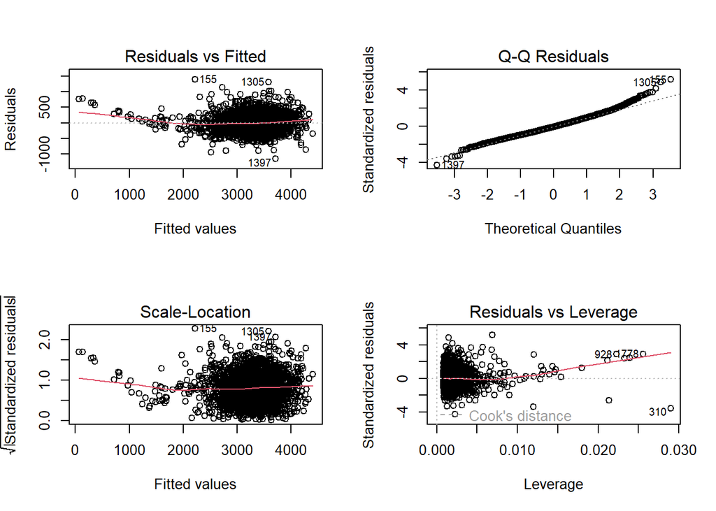

```r
par(mfrow=c(2,2))
plot(mod6a)
```

```r
shapiro.test(residuals(mod6a))
```

```
##
##  Shapiro-Wilk normality test
##
## data:  residuals(mod6a)
## W = 0.98868, p-value = 3.6e-13
```

```r
lmtest::bptest(mod6a)
```

```
##
##  studentized Breusch-Pagan test
##
## data:  mod6a
## BP = 9.3293, df = 4, p-value = 0.05338
```

```r
lmtest::dwtest(mod6a)
```

```
##
##  Durbin-Watson test
##
## data:  mod6a
## DW = 1.9555, p-value = 0.1325
## alternative hypothesis: true autocorrelation is greater than 0
```

#### Anche eliminando l’osservazione con distanza di cook superiore a 0.6 il modello continua a non rispettare i requisiti di normalità. Vengono però soddisfatti i requsiti di varianza costante e non è presente autocorrelazione tra i residui.

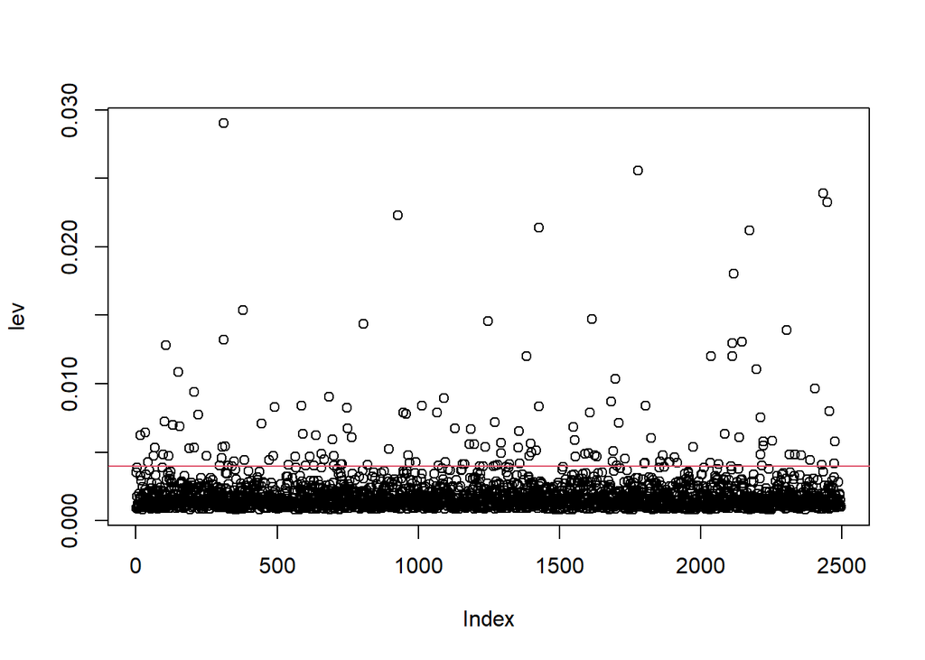

```r
#lavarage
n=nrow(data)
lev=hatvalues(mod6a)
plot(lev)
p=sum(lev)
soglia=2*p/n
abline(h=soglia,col=2)
```

```r
#lev[lev>soglia]
```

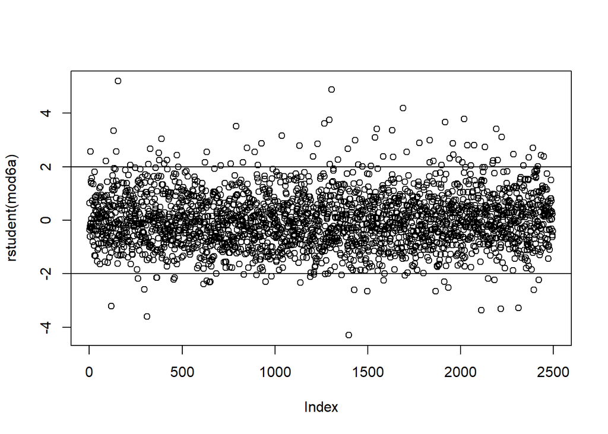

```r
#outlier
plot(rstudent(mod6a))
abline(h=c(-2,2))
```

```r
car::outlierTest(mod6a)
```

```
##       rstudent unadjusted p-value Bonferroni p
## 155   5.200999         2.1435e-07   0.00053523
## 1305  4.890087         1.0721e-06   0.00267700
## 1397 -4.295929         1.8064e-05   0.04510500
```

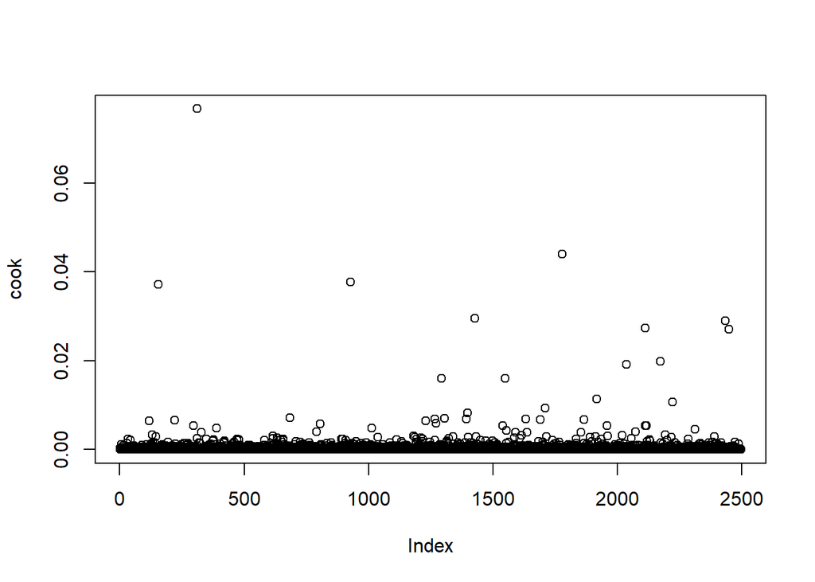

```r
#distanza di cook
cook=cooks.distance(mod6a)
plot(cook)
```

```r
influent_point = which(cook >0.6)
print(influent_point)
```

```
## named integer(0)
```

#### In questo modello non sono presenti osservazioni con una distanza di cook al di sopra della soglia di allarme.

```r
summary(mod7)$adj.r.squared
```

```
## [1] 0.7256742
```

```r
summary(mod6a)$adj.r.squared
```

```
## [1] 0.7357659
```

#### Rimuovendo la singola osservazione (1549) ottego un’aumento dell’1% nella varianza spiegata.

```r
BIC(mod7,mod6a)
```

```
##       df      BIC
## mod7   6 35194.06
## mod6a  6 35083.12
```

#### Dai risultati del BIC il mod6a risulta migliore, con un buon compromesso tra semplicità e buona variabilità spiegata che è pari al 73.6%.

```r
# per fare previsione del peso sostituisco le variabili numeriche mancanti con la loro media

dati_previsione = data.frame(N.gravidanze=3,Gestazione=39,Tipo.parto="Ces",
                             Lunghezza=mean(Lunghezza),Cranio=mean(Cranio),
                             Sesso="F")

migliore_previsione_1 = predict(mod6a,dati_previsione)
migliore_previsione_1
```

```
##        1
## 3244.192
```

# 8-Cerca di creare qualche rappresentazione grafica che aiuti a visualizzare il modello. Se è il caso

semplifica quest’ultimo.

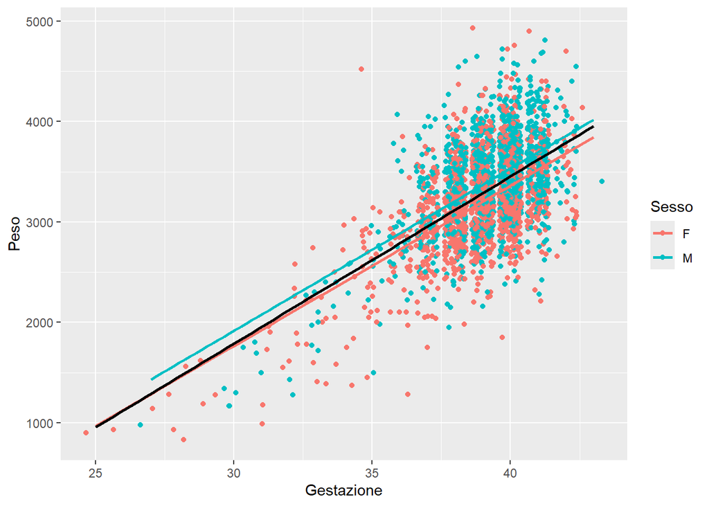

```r
ggplot(dati_no_outlier)+
  geom_point(aes(x=Gestazione,
                 y=Peso,
                 col=Sesso),position = "jitter")+
  geom_smooth(aes(x=Gestazione,
                  y=Peso,
                  col=Sesso),se = F,method = "lm")+
  geom_smooth(aes(x=Gestazione,
                  y=Peso),col="black",
              se = F,method = "lm")
```

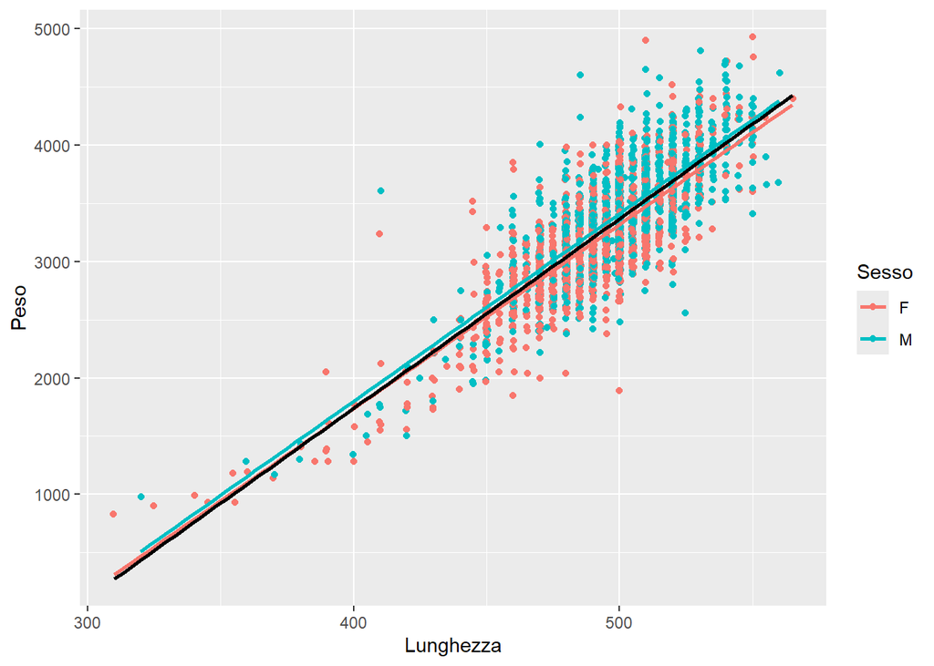

```r
ggplot(dati_no_outlier)+
  geom_point(aes(x=Lunghezza,
                 y=Peso,
                 col=Sesso),position = "jitter")+
  geom_smooth(aes(x=Lunghezza,
                  y=Peso,
                  col=Sesso),
                  method="lm",
                  se = F)+

  geom_smooth(aes(x=Lunghezza,
                  y=Peso),col="black",
              se = F,method = "glm")
```

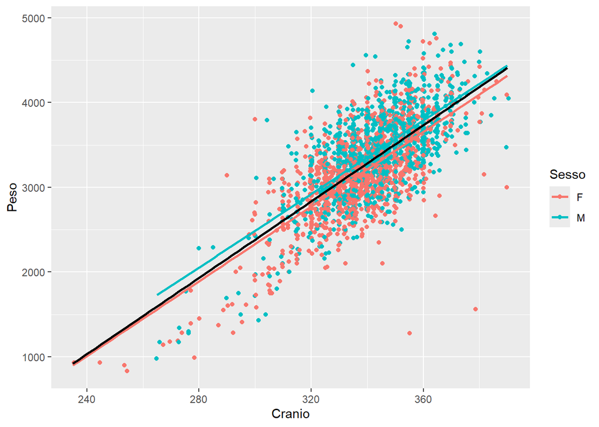

```r
ggplot(dati_no_outlier)+
  geom_point(aes(x=Cranio,
                 y=Peso,
                 col=Sesso),position = "jitter")+
  geom_smooth(aes(x=Cranio,
                  y=Peso,
                  col=Sesso),se = F,method = "lm")+
  geom_smooth(aes(x=Cranio,
                  y=Peso),col="black",
              se = F,method = "lm")
```